# Reproducible Research: Peer Assessment 1

## Loading and preprocessing the data

```r
#Create new working directory for this project
wd <- getwd()
if (!file.exists("./Project1")) {dir.create("./Project1")}
newWD <- paste(wd,"/Project1", sep="")
setwd(newWD)

#get source data file from my local repo clone
fileURL <- "~/DataScience/datasciencecoursera/RepData_PeerAssessment1/activity.zip"

#unzip file and save to new working dir
unzip(fileURL, exdir = newWD, overwrite=TRUE)

#read data
activityDataRaw <- read.csv("activity.csv")
dim(activityDataRaw) # This is to confirm we have the expected
```

```
## [1] 17568     3
```

```r
head(activityDataRaw)
```

```
##   steps       date interval
## 1    NA 2012-10-01        0
## 2    NA 2012-10-01        5
## 3    NA 2012-10-01       10
## 4    NA 2012-10-01       15
## 5    NA 2012-10-01       20
## 6    NA 2012-10-01       25
```

This output confirms that we have the expected data as indicated in the instructions.

## What is mean total number of steps taken per day?

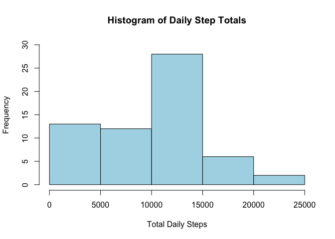

```r
# 1. Calculate the total number of steps taken per day
# I decided simply to use base graphics for this task. Nothing fancy.
dailySteps <- tapply(activityDataRaw$steps, activityDataRaw$date, sum,
                     na.rm = TRUE) #we were told to ignore NAs for this part

# 2. Make a histogram of the total number of steps taken each day
hist(dailySteps, main="Histogram of Daily Step Totals",
     xlab="Total Daily Steps", col="lightblue", ylim=c(0, 30))
```

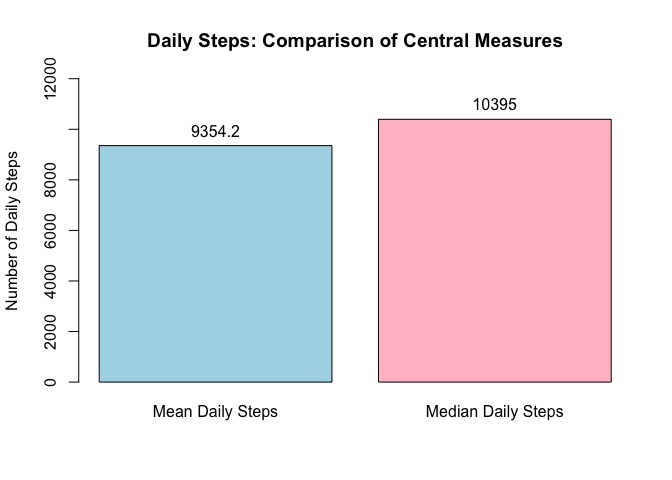

```r
# 3. Calculate and report the mean and median
# of the total number of steps taken per day
meanDailySteps <- mean(dailySteps)
medianDailySteps <- median(dailySteps)

mmPlot <-
    barplot(c(meanDailySteps, medianDailySteps),
            main="Daily Steps: Comparison of Central Measures",
            ylim=c(0, 12000), names.arg=c("Mean Daily Steps", "Median Daily Steps"),
            ylab="Number of Daily Steps", col=c("lightblue", "pink"))
# Now add the y values as text
text(y=c(meanDailySteps, medianDailySteps),
     x=mmPlot,
     pos=3, #Place data labels above the bars
     labels=as.character(c(round(meanDailySteps, digits=1), medianDailySteps)))
```

Notice in plot that the median is almost 1041 steps more than the mean.

## What is the average daily activity pattern?

```r
# 1. Make a time series plot (i.e. type = "l" ) of the 5-minute interval (x-axis)
#    and the average number of steps taken, averaged across all days (y-axis)
# 2. Which 5-minute interval, on average across all the days in the dataset,
#    contains the maximum number of steps?
```

Question 1 is slightly confusing, but here is my interpretation of it: He is asking us to compute the average number of steps taken for each 5-min interval. Since there are 288 5-minute samples in a day, we will have 288 data points, each one being the mean for that same interval across all 61 days (fewer days if some are NA).

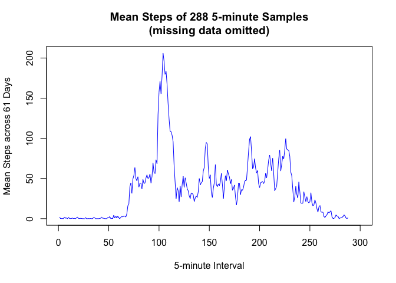

```r
# Question 1 Make a time series plot of the 5-minute interval (x-axis)
# and the average number of steps taken, averaged across all days (y-axis)
intervalMeanSteps <- tapply(activityDataRaw$steps, activityDataRaw$interval,
                     mean, na.rm = TRUE)
plot(intervalMeanSteps, type="l",
     main="Mean Steps of 288 5-minute Samples\n(missing data omitted)",
     xlab="5-minute Interval", ylab="Mean Steps across 61 Days", col="blue",
     xlim=c(0, 300))
```

```r
# Question 2 Which 5-minute interval, on average across all the days
# in the dataset, contains the maximum number of steps?
```

intervalMeanSteps has length 288 and each value is the mean of the steps for that interval across all days, as we can see here:

```r
length(intervalMeanSteps)
```

```
## [1] 288
```

```r
head(intervalMeanSteps)
```

```
##         0         5        10        15        20        25
## 1.7169811 0.3396226 0.1320755 0.1509434 0.0754717 2.0943396
```

So now we just have to find which of those intervals has the highest value. The highest value is:

```r
max(intervalMeanSteps)
```

```
## [1] 206.1698
```

So let’s find out the index of that interval

```r
indexOfmaxMeanStepInterval <- which(intervalMeanSteps==max(intervalMeanSteps))
indexOfmaxMeanStepInterval
```

```
## 835
## 104
```

So the 104th element of intervalMeanSteps refers to interval 835 Looking at the plot, this appears correct since the highest point looks slightly above 200 on the y-axis and slightly higher than 100 on the x-axis.

That is our answer, but to double-check its correctness:

```r
intervalMeanSteps[indexOfmaxMeanStepInterval[[1]]]
```

```
##      835
## 206.1698
```

I.e. this is correct. So the answer to question 2 is that interval 835, on average, has the highest number of steps: 206.1698

## Imputing missing values

```r
# 1. Calculate and report the total number of missing values in the dataset
#    (i.e. the total number of rows with NA s)

missingSteps <- is.na(activityDataRaw$steps)
sum(missingSteps) #This shows our answer.
```

```
## [1] 2304
```

We can verify this independently by calling the following, which shows the number of NAs at the lower left of the output:

```r
summary(activityDataRaw)
```

```
##      steps                date          interval
##  Min.   :  0.00   2012-10-01:  288   Min.   :   0.0
##  1st Qu.:  0.00   2012-10-02:  288   1st Qu.: 588.8
##  Median :  0.00   2012-10-03:  288   Median :1177.5
##  Mean   : 37.38   2012-10-04:  288   Mean   :1177.5
##  3rd Qu.: 12.00   2012-10-05:  288   3rd Qu.:1766.2
##  Max.   :806.00   2012-10-06:  288   Max.   :2355.0
##  NA's   :2304     (Other)   :15840
```

```r
# 2.  Devise a strategy for filling in all of the missing values in the dataset.
# 3.  Create a new dataset that is equal to the original dataset but with the
#     missing data filled in.
```

I decided to round the mean for each 5-min interval to the nearest whole number e.g. for interval 1840, the mean is 85.33962, so the round() of that is 85, which comes from round(intervalMeanSteps[[“1840”]]). To implement this strategy I define a function ‘fillInNA’ that takes a data frame (which will be called with the activityDataRaw) and an array of indices indicating the rows in the data frame that contain NA values. This function returns the imputed, or ‘filled’ in data which I save in variable ‘activityDataFilled’.

```r
# get row indices of raw data with missing steps
indicesOfNA <- which(missingSteps, arr.ind=TRUE)

# Define function on data frame and indices into that df
# to replace the NA vals in the 'steps' var with the round of the steps
# in the same interval using 'intervalMeanSteps', previously computed.
fillInNA <- function(df, indices) {
    # replace each NA in 'steps' var with the nearest whole number
    # from the corresponding interval previously computed in intervalMeanSteps
    for (i in indices) {
        intervalOfNA <- df[i, "interval"]
        #next line references intervalMeanSteps as a global
        df$steps[i] <- round(intervalMeanSteps[[as.character(intervalOfNA)]])
    }
    df
}

activityDataFilled <- fillInNA(activityDataRaw, indicesOfNA)
```

We will now use this new data frame, activityDataFilled, to plot a new histogram and then compare that to the histogram made on the original data frame with NA values.

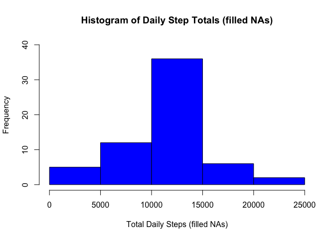

```r
# 4. Make a histogram of the total number of steps taken each day and Calculate
#    and report the mean and median total number of steps taken per day.
#    Do these values differ from the estimates from the first part of the assignment?
#    What is the impact of imputing missing data on the estimates
#    of the total daily number of steps?

dailyStepsFilled <- tapply(activityDataFilled$steps, activityDataFilled$date,
                           sum)

#Make a histogram of the total number of steps taken each day
hist(dailyStepsFilled, main="Histogram of Daily Step Totals (filled NAs)",
     xlab="Total Daily Steps (filled NAs)", col="blue", ylim=c(0, 40))
```

Notice how the shape of this histogram is VERY different compared to the first that used the raw data. Also quite different is the absolute height of the historgram bars, as would be expected since this new filled data frame contains more data.

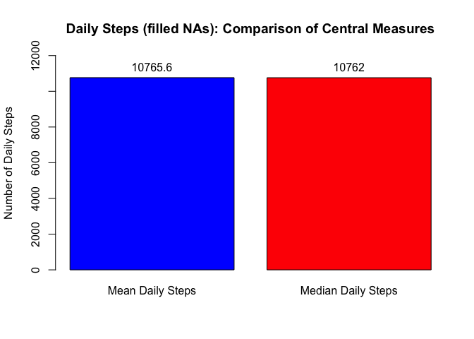

```r
#Instructions from question 4: Calculate and report the mean and median
#of the total number of steps taken per day
meanDailyStepsFilled <- mean(dailyStepsFilled)
medianDailyStepsFilled <- median(dailyStepsFilled)

mmPlotFilled <-
    barplot(c(meanDailyStepsFilled, medianDailyStepsFilled),
            main="Daily Steps (filled NAs): Comparison of Central Measures",
            ylim=c(0, 12000),
            names.arg=c("Mean Daily Steps", "Median Daily Steps"),
            ylab="Number of Daily Steps", col=c("blue", "red"))
# Now add the y values as text
text(y=c(meanDailyStepsFilled, medianDailyStepsFilled),
     x=mmPlotFilled,
     pos=3, #Place data labels above the bars
     labels=as.character(c(round(meanDailyStepsFilled, digits=1),
                           medianDailyStepsFilled)))
```

Now using the imputed data, notice how the mean and median are nearly identical.

Obviously, imputing the missing values indeed makes a huge difference in the graph compared to the raw numbers. With imputed values, the mean and median are nearly identical, whereas with the raw data the difference was almost 1041 steps.

## Are there differences in activity patterns between weekdays and weekends?

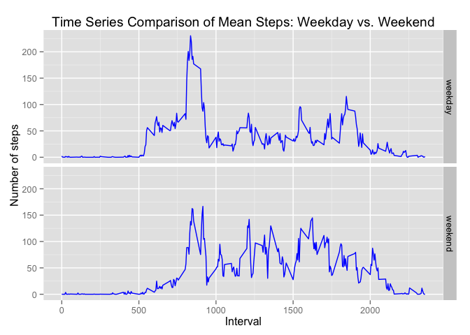

```r
# For this part the weekdays() function may be of some help here. Use the dataset
# with the filled-in missing values for this part.
# 1. Create a new factor variable in the dataset with two levels – “weekday” and
#    “weekend” indicating whether a given date is a weekday or weekend day.
# 2. Make a panel plot containing a time series plot (i.e. type = "l" )
#    of the 5-minute interval (x-axis) and the average number of steps taken,
#    averaged across all weekday days or weekend days (y-axis). See the README file
#    in the GitHub repository to see an example of what this plot should look
#    like using simulated data.

#define fn to return Boolean vector where T means weekend
isWeekend <- function(dateAsCharacter) {
    # dateAsCharacter is a vector of character dates
                weekdays(as.Date(dateAsCharacter)) %in% c("Saturday", "Sunday")
                }
# get weekend vector of all dates based on the imputed dataset
is.weekend <- isWeekend(activityDataFilled$date)

#replace T with 'weekend' and F with 'weekday'
is.weekend[is.weekend==TRUE] <- "weekend"
is.weekend[is.weekend==FALSE] <- "weekday"

#add new 2-level factor variable for weekend/weekday
activityDataFilled$TypeOfDay <- as.factor(is.weekend)

# Now make the panel plot and I'll use ggplot2

library(ggplot2)

tsPlot <- ggplot(activityDataFilled, aes(interval, steps))
tsPlot + facet_grid(TypeOfDay ~ .) +
    xlab("Interval") +
    ylab("Number of steps") +
    ggtitle("Time Series Comparison of Mean Steps: Weekday vs. Weekend") +
    stat_summary(fun.y="mean", geom=c("line"), color="blue")
```